# 2. NumPy_Q slides

## NumPy Advanced

### Da-Wei Chiang

## 大綱

- Numpy的UFuncs
- Broadcasting
- Mask
- Fancy Index
- 其他常用函數

## Numpy UFuncs

- `Numpy`的運算為向量化運算(Element Wise)
- 為了達到向量化運算，`Numpy`提供了許多的`Universal Functions`

## 基礎算術運算

- 基礎運算`UFuncs`

```
np.add()  加法
np.subtract()  減法
np.multiply()  乘法
np.divide() 除法
np.power()  指數
np.mod()    餘數
```

```python
#範例

import numpy as np
x = np.array([1, 2, 3])
y = np.array([4, 5, 6])
add = np.add(x, y)
print("使用add = ", add)
print("使用+ = ", x+y)
subtract = np.subtract(x, y)
print("使用substract = ", subtract)
print("使用- = ", x-y)
multiply = np.multiply(x, 2)
print("使用multiply = ", multiply)
print("使用* = ", x*2)
```

```
使用add =  [5 7 9]
使用+ =  [5 7 9]
使用substract =  [-3 -3 -3]
使用- =  [-3 -3 -3]
使用multiply =  [2 4 6]
使用* =  [2 4 6]
```

## 練習

- 自行建立兩個`ndarray`，並練習使用除法、指數、餘數

## 絕對值

```
np.abs()
```

```python
## 範例

import numpy as np


ndarray = np.array([-1, 2, 4, 5, -8, 0])
print(ndarray)
print(np.abs(ndarray))
```

```
[-1  2  4  5 -8  0]
[1 2 4 5 8 0]
```

## 指數與對數

```
np.power()


np.log2()
np.log10()
```

```python
## 範例

import numpy as np

x = np.array([1, 2, 4])
print(np.power(2, x))
print(np.log2(x))
print(np.log10(x))
```

```
[ 2  4 16]
[0. 1. 2.]
[0.         0.30103    0.60205999]
```

## 練習

- 練習使用絕對值、指數與對數

## 加總、最大值、最小值、中位數、平均值

```
np.sum()
np.max()
np.min()
np.median()
np.mean()
```

```python
## 範例

import numpy as np

num = np.random.randint(1, 100, 11)
print(num)
print(np.sum(num))
print(np.max(num))
print(np.min(num))
print(np.median(num))
print(np.mean(num))
```

```
[29 42 29 92 94 22 83 67 21 52  7]
538
94
7
42.0
48.90909090909091
```

## python函數 vs numpy函數

```python
import time, random

x = np.random.randint(1, 100, 100000)

print("使用python內建函數sum, 計算x加總")
start = time.time()
python_sum = sum(x)
end = time.time()
print("python內建函數sum執行時間：%f 秒" % (end - start))
print("- -")
print("使用numpy函數sum, 計算x加總")
start = time.time()
numpy_sum = np.sum(x)
end = time.time()
print("numpy函數sum執行時間：%f 秒" % (end - start))
print("- - - - - - - - - - - - - - - - ")
print("使用python內建函數max, 計算x最大值")
start = time.time()
python_sum = max(x)
end = time.time()
print("python內建函數max執行時間：%f 秒" % (end - start))
print("- -")
print("使用numpy函數max, 計算x最大值")
start = time.time()
numpy_sum = np.max(x)
end = time.time()
print("numpy函數max執行時間：%f 秒" % (end - start))
```

```
使用python內建函數sum, 計算x加總
python內建函數sum執行時間：0.029616 秒
- -
使用numpy函數sum, 計算x加總
numpy函數sum執行時間：0.000330 秒
- - - - - - - - - - - - - - - -
使用python內建函數max, 計算x最大值
python內建函數max執行時間：0.012616 秒
- -
使用numpy函數max, 計算x最大值
numpy函數max執行時間：0.000306 秒
```

## 練習

- 使用random函數與numpy的random函數, 隨機產生1000個介於1~100的正整數
- 比較兩者執行時間差異

## 練習

- 隨機產生`(1~10)`一個`5*4`的`ndarray`
- 請印出該矩陣、矩陣的形狀、該矩陣直向的加總
- 例：

```
#假設隨機產生的矩陣如下
[[9 8 7 1]
 [3 8 4 2]
 [4 9 4 9]
 [5 7 5 1]
 [6 9 1 6]]

#形狀為(5,4)
#直向加總為[27 41 21 19]
```

## 內積

```
ndarray.dot()

ndarray.T

np.inner()
```

```python
## 範例

import numpy as np

A = np.array([[1, 2], [3, 4]])
B = np.array([[5, 6], [7, 8]])
print("A", A, sep="\n")
print("B", B, sep="\n")
print("inner", np.inner(A, B), sep="\n")
A = np.array([[1, 0, 2], [-1, 3, 1]])
B = np.array([[3, 1], [2, 1], [1, 0]])
print("A", A, sep="\n")
print("B", B, sep="\n")
print("dot", A.dot(B), sep="\n")
print("A Transpose", A.T, sep="\n")
```

```
A
[[1 2]
 [3 4]]
B
[[5 6]
 [7 8]]
inner
[[17 23]
 [39 53]]
A
[[ 1  0  2]
 [-1  3  1]]
B
[[3 1]
 [2 1]
 [1 0]]
dot
[[5 1]
 [4 2]]
A Transpose
[[ 1 -1]
 [ 0  3]
 [ 2  1]]
```

## Broadcasting

- `Numpy`與算術運算子結合的計算法則

```python
## 範例(請猜猜以下執行結果)

import numpy as np

num = np.array([1, 2, 3])
print(num*3)
```

```python
## 範例(請猜猜以下執行結果)

import numpy as np

num1 = np.ones((3,3))
num2 = np.full((3,3), 2)
print(num1+num2)
```

```python
## 範例(請猜猜以下執行結果)

import numpy as np

num1 = np.array([1, 2, 3])
num2 = np.full((3,3), 2)
print(num1+num2)
```

```python
## 範例(請猜猜以下執行結果)

import numpy as np

num1 = np.arange(3)
print(num1)
num2 = np.arange(3).reshape(3,1)
print(num2)
print(num1+num2)
```

## Broadcasting 圖形說明

[figure not shown]

```python
## 範例(請猜猜以下執行結果)

import numpy as np

num1 = np.arange(16).reshape(4,4)
num2 = np.arange(4).reshape(2,2)

print(num1)
print(num2)
print(num1+num2)
```

## Broadcasting 規則整理

- 當兩個不同維度的`ndarray`要進行運算時，低維度的`ndarray`會墊充原本的元素
- 當兩個`ndarray`的任何維度都不相等時，會拉長形狀是1的`ndarray`，使兩個`ndarray`形狀相同
- 當兩個`ndarray`的任何維度都不相等時，且沒有形狀為1時，則產生錯誤

## 練習

- 請試著使用`Numpy`內建函數建立`ndarray`
- 嘗試使用`BroadCasting`

## Mask

- `Numpy`與比較運算子結合的計算法則

## 比較運算子對應的ufunc

```
np.equal()       #==
np.not_equal()   #!=
np.less()        #<
np.less_equal()    #<=
np.less_greater()  #>
np.greater_equal() #>=
```

```python
## 範例
import numpy as np

num = np.random.randint(1,20,20)
print("num : ", num)
print("num>10 : ", num>10)
print("num>=15 : ", num>=15)
print("num==10 : ", num==10)
print("num<10 : ", num<10)
print("num<=15 : ", num<=15)
print("num!= : ", num!=5)
```

```
num :  [ 6 14 19 16 18  5 15 13  3  1 17 12  6 19  4 17 19  5  8 16]
num>10 :  [False  True  True  True  True False  True  True False False  True  True
 False  True False  True  True False False  True]
num>=15 :  [False False  True  True  True False  True False False False  True False
 False  True False  True  True False False  True]
num==10 :  [False False False False False False False False False False False False
 False False False False False False False False]
num<10 :  [ True False False False False  True False False  True  True False False
  True False  True False False  True  True False]
num<=15 :  [ True  True False False False  True  True  True  True  True False  True
  True False  True False False  True  True False]
num!= :  [ True  True  True  True  True False  True  True  True  True  True  True
  True  True  True  True  True False  True  True]
```

```python
## 範例

import numpy as np

num = np.random.randint(0, 10, 20).reshape(5,4)
print(num)
print(np.count_nonzero(num))   #計算非0元素個數
print(np.sum(num>0))     #計算大於(非)0元素個數
```

```
[[2 7 7 0]
 [0 7 7 7]
 [4 3 8 3]
 [5 3 5 4]
 [5 6 3 0]]
17
17
```

## 練習

- 使用`numpy`內建函數建構一個`5*4`隨機產生介於0~10的`ndarray`
- 計算各個`row`中大於5的元素個數
- 例：

  ```
    隨機產生的ndarray：
    [[8 3 2 2]
     [2 7 8 3]
     [6 8 9 5]
     [3 9 6 0]
     [0 5 5 5]]

     >5元素個數：[1 2 3 2 0]
  ```

## 查詢某個元素

```
np.any()  #某元素是否存在？
np.all()  #所有值都是？
```

```python
## 範例

import numpy as np

num = np.random.randint(0, 10, 20).reshape(5,4)
print(num)
print(np.any(num<2))
print(np.any(num>11))
print(np.all(num<11))
```

```
[[7 4 3 6]
 [4 2 3 7]
 [2 3 8 4]
 [5 7 4 5]
 [3 4 0 0]]
True
False
True
```

## all與any可以不寫條件

[output not shown]

```python
## 範例

import numpy as np

ndarray = np.array([1, 2, 3, 4, 5])
print(np.all(ndarray))
print(ndarray.all())
print(np.any(ndarray))
print("- - - - -")
ndarray = np.array([0, 1, 2, 3, 4, 5])
print(np.all(ndarray))
print(ndarray.all())
print(np.any(ndarray))
print(ndarray.any())
```

```
True
True
True
- - - - -
False
False
True
True
```

```python
## 請猜猜以下執行結果
import numpy as np

ndarray = np.array([[1, 3, 5],
                    [2, 4, 6],
                    [3, 7, 9]])
print(np.all(ndarray%2==0))
print(np.all(ndarray%2==0, axis=0))
print(np.all(ndarray%2==0, axis=1))
print("- - - - - - - -")
print(np.any(ndarray%2==0))
print(np.any(ndarray%2==0, axis=0))
print(np.any(ndarray%2==0, axis=1))
```

```python
## 請猜猜以下執行結果
import numpy as np

ndarray = np.array([[1, 3, 5],
                    [2, 4, 6],
                    [3, 7, 9]])
print(np.all(ndarray%2==0))
print(np.all(ndarray%2==0, axis=0))
print(np.all(ndarray%2==0, axis=1))
print("- - - - - - - -")
print(np.any(ndarray%2==0))
print(np.any(ndarray%2==0, axis=0))
print(np.any(ndarray%2==0, axis=1))
```

```python
## keepdims範例
import numpy as np

ndarray = np.array([[1, 4, 7],
                    [2, 5, 8],
                    [3, 6, 9]])
print(np.all(ndarray<=5))
print('- '*5)
print(np.all(ndarray<=5, keepdims=True))   #觀察結果差異
print('- '*5)
print(np.all(ndarray<=5, axis=0))
print('- '*5)
print(np.all(ndarray<=5, axis=0, keepdims=True))   #觀察結果差異
print('- '*5)
print(np.all(ndarray<=5, axis=1))
print('- '*5)
print(np.all(ndarray<=5, axis=1, keepdims=True))   #觀察結果差異
```

```
False
- - - - -
[[False]]
- - - - -
[ True False False]
- - - - -
[[ True False False]]
- - - - -
[False False False]
- - - - -
[[False]
 [False]
 [False]]
```

## 練習

- 請自行練習`any`與`all`

## 邏輯運算子(& | ~)

- `and`使用`&`
- `or`使用`|`
- `not`使用`~`

```python
## 範例

import numpy as np

num = np.random.randint(0, 10, 20).reshape(5,4)
print(num)
print((num>2) & (num<5))
print(np.sum((num>2) & (num<5)))
```

```
[[5 5 4 4]
 [7 4 2 4]
 [4 7 0 9]
 [9 6 4 1]
 [8 5 9 7]]
[[False False  True  True]
 [False  True False  True]
 [ True False False False]
 [False False  True False]
 [False False False False]]
6
```

## 練習

- 使用`numpy`內建函數建構一個`5*5`隨機產生介於0~10的`ndarray`
- 計算各個`column`中小於3或大於8的元素個數
- 例：

  ```
    隨機產生的ndarray：
    [[7 7 6 0 4]
     [0 4 8 5 6]
     [6 9 5 2 4]
     [0 3 5 0 8]
     [5 1 2 0 8]]

     <3或>8的元素個數：[2 2 1 4 0]
  ```

## 布林遮罩

- `ndarray`透過`bool`取值

```python
## 範例
import numpy as np

num = np.random.randint(1,20,20)
print("原先的ndarray")
print("\tnum : ", num)
print()
print("ndarray搭配比較運算子")
print("\tnum元素是否介於5~15之間 : ", (num>5) & (num<15))
print()
print("ndarray搭配比較運算子與邏輯運算子")
print("\t num介於5~15之間的元素個數有 :%s個" %np.sum((num>5) & (num<15)))
print("- - - - - - - - - - - -")
print("使用布林遮罩")
print("\tnum介於5~15之間的元素有：", num[(num>5) & (num<15)])
```

```
原先的ndarray
	num :  [10  3  1  7 17  8 19  7 17  4  7  8 10 10 14  5  7 13  5 17]

ndarray搭配比較運算子
	num元素是否介於5~15之間 :  [ True False False  True False  True False  True False False  True  True
  True  True  True False  True  True False False]

ndarray搭配比較運算子與邏輯運算子
	 num介於5~15之間的元素個數有 :11個
- - - - - - - - - - - -
使用布林遮罩
	num介於5~15之間的元素有： [10  7  8  7  7  8 10 10 14  7 13]
```

```python
# 範例

import numpy as np

num = np.random.randint(0, 10, 20).reshape(5,4)
print(num)
print((num>2) & (num<5))
print(np.sum((num>2) & (num<5)))
print(num[(num>2) & (num<5)])
```

```
[[2 7 2 9]
 [4 5 0 1]
 [2 4 6 8]
 [0 8 5 9]
 [3 2 1 8]]
[[False False False False]
 [ True False False False]
 [False  True False False]
 [False False False False]
 [ True False False False]]
3
[4 4 3]
```

## 練習

- 使用`numpy`內建函數建構一個`5*5`隨機產生介於0~10的`ndarray`
- 列出`column`中小於3或大於8的元素
- 例：

  ```
    隨機產生的ndarray：
    [[4 7 7 7 1]
     [7 0 3 6 8]
     [1 2 7 1 5]
     [2 8 9 7 7]
     [7 8 4 9 7]]

     小於3或大於8的元素：[1 2 0 2 9 1 9 1]    # 注意順序
  ```

## Numpy 取值方式

- 一般索引
- 切片
- 布林遮罩
- 華麗索引

## Fancy Index

- 取值的方式：以陣列的方式傳遞索引值

```python
# 範例

import numpy as np

num = np.random.randint(1, 20, 10)
print("num = ", num)
print("取索引值1, 5, 6的值", num[1], num[5], num[6])
print("- - - - - - - - -")
print("使用Fancy index")
index = [1, 5, 6]
print(num[index])
```

```
num =  [18 19 18 11 18  8 10  8  3  9]
取索引值1, 5, 6的值 19 8 10
- - - - - - - - -
使用Fancy index
[19  8 10]
```

```python
# 範例


import numpy as np


num = np.random.randint(1, 50, 25)
print("num = ", num)
index = np.random.randint(0, 25, 4).reshape(2,2)
print("index = ", index)
print("- - - - -")
print(num[index]) #fancy index取值的形狀與index有關與被索引陣列無關
```

```
num =  [48 46  5  9 26  5 10 37 45 10 26 32  1 15 17 15 21 46 23 15 30 30 34 47
 37]
index =  [[15 17]
 [21  0]]
- - - - -
[[15 46]
 [30 48]]
```

## 練習

- 建構一個`5*5`的`ndarray`, 其值為`0 ~ 24`
- 使用`fancy index`抓取值為`1, 11, 16`

## Fancy index 改值

```python
## 範例

import numpy as np

num = np.arange(10)
index = np.random.randint(0,10, 3)
print("num = ", num)
print("index = ", index)
num[index] = 100
print(num)
```

```
num =  [0 1 2 3 4 5 6 7 8 9]
index =  [1 6 2]
[  0 100 100   3   4   5 100   7   8   9]
```

## 練習

- 建立一個2維的`ndarray`，練習使用`fancy index`改值

## `numpy`其他常用函數

- `where`
- `sort`
- `amax、amin`
- `flatten`方法
- `ravel`方法
- `tile`方法
- `newaxis`屬性
- 其它常用基本函數

## where指定查詢

```
index_Variable = np.where(condition, replace1, replace2)

#參數介紹
condition:判斷條件
replace1:若為True替換為此
replace2:若為False替換為此

## 注意：where查詢出的結果為index
```

```python
## 範例

import numpy as np

num = np.array([5, 4, 1, 8, 2, 3, 9, 12])
print(num)
index = np.where(num<5)
print(index)
```

```
[ 5  4  1  8  2  3  9 12]
(array([1, 2, 4, 5]),)
```

## 練習

- 請建立`ndarray`, 並嘗試使用`np.where`

```python
## 請猜猜以下執行結果

import numpy as np

num = np.array([5, 4, 1, 8, 2, 3, 9, 12]).reshape(2, -1)
print(num)
print("- - - - - - -")
index = np.where(num%2==0)
print(index)
```

```python
## 請猜猜以下執行結果

import numpy as np

num = np.array([6, 8, 20, 18, 25, 30, 24, 22, 14, 15]).reshape(-1, 2)
print(num)
value = np.where(num>=20, '>=20', '<20')
print(value)
```

```python
## 請猜猜以下執行結果

import numpy as np

num1 = np.array([3, 1, 2, 3, 4, 5])
num2 = np.array([6, 7, 8, 9, 10, 11])
value = np.where(num1%2==0, num1, num2)
print(value)
```

## 練習

- 建構一個`ndarray`其值如下
  - `['', 17, 12, '', 20, 18, 17, '', '']`
- 請將空值的部分以平均值填滿並輸出結果

```
注意：該題禁止使用迴圈, 平均值請由程式自動計算（即增加元素值也會自動計算平均值而不影響執行結果）
```

## 練習

- 建構一個年紀的`ndarray`其值如下
  - `[28, 19, 33, 42, 18, 50, 62, 60, 29, 22]`
- 請更改該`ndarray`的值
  - 若小於30歲(包含30歲)則為少年
  - 若為31~50歲(包含50歲)則為中年
  - 若大於50歲則為老年

    ```
    注意：該題禁止使用迴圈
    ```

## 排序

```
np.sort()   #回傳排序結果
np.argsort()  #回傳排序結果索引值
```

```python
# 範例 - sort

import numpy as np

num = np.random.randint(0, 100, 10)
print(num)
num = np.sort(num)
print(num)
```

```
[83 46 76 22 22 30 35 77 39 48]
[22 22 30 35 39 46 48 76 77 83]
```

```python
# 範例 - argsort

import numpy as np

num = np.array([5, 2, 3, 1])
print(np.argsort(num))
print(np.sort(num))
```

```
[3 1 2 0]
[1 2 3 5]
```

```python
## 請猜猜以下執行結果

import numpy as np

num = np.array([6, 2, 7, 1, 12, 3, 9, 10])
np.sort(num)
print(num)
```

```python
## 請猜猜以下執行結果

import numpy as np

num = np.array([6, 2, 7, 1, 12, 3, 9, 10]).reshape(2, -1)
num = np.sort(num)
print(num)
```

## 練習

- 請隨機產生10個數為介於0~100的`ndarray`
  - 如果隨機產生的數有大於80的數則有大到小輸出矩陣, 否則由小到大輸出矩陣

## 練習

- 請隨機產生`10`個數值介於`0 ~ 100`且為`2*5`的`ndarray`
  - 輸出該隨機產生的ndarray
  - 對於每個元素由小到大排序的結果

```
例：
    隨機產生的ndarray：
        [[92 22  2 57 68]
         [ 9 31 34 66 95]]
    所有元素由小到大排序：
        [[ 2  9 22 31 34]
         [57 66 68 92 95]]
```

## 最大值與最小值

```
np.amax() #取最大值
np.amin() #取最小值

np.argmax() #取最大值索引值
np.argmin() #取最小值索引值
```

```python
## 範例

import numpy as np

num = np.array([1, 4, 2, 0, 3, 6, 10, 8])

print(np.amax(num))
print(np.amin(num))
print(np.argmax(num))
print(np.argmin(num))
```

```
10
0
6
3
```

## 除了`numpy`的方法, 也可以使用`ndarray`的物件方法

```python
## 範例

import numpy as np

num = np.array([1, 4, 2, 0, 3, 6, 10, 8])

print(num.max())
print(num.min())
print(num.argmax())
print(num.argmin())
```

```
10
0
6
3
```

## 不論是`numpy`方法還是`ndarray`方法, 都可在不降維的情況下找到結果

```python
## 範例
import numpy as np

num = np.array([1, 4, 2, 0, 3, 6, 10, 8])

print(np.amax(num, keepdims=True))
print(np.amin(num, keepdims=True))
print(num.max(keepdims=True))
print(num.min(keepdims=True))
```

## 練習

- 隨機產生`10`個介於`0 ~ 100`的數建構`ndarray`
  - 輸出隨機產生的`ndarray`
  - 若該`ndarray`中有大於5個數為偶數則輸出偶數的最大值與偶數的最小值
  - 若該`ndarray`中有小於或等於5個數為偶數則輸出奇數的最大值與奇數的最小值

```
注意:該練習禁止使用迴圈
```

## `flatten`方法

```
ndarray_Variable.flatten()
```

```python
## 範例

import numpy as np

num = np.arange(1, 10).reshape(3, -1)
print(num)
num_flatten = num.flatten()
print(num_flatten)

num = np.arange(1, 9).reshape(2, 2, 2)
print(num)
num_flatten = num.flatten()
print(num_flatten)
```

```
[[1 2 3]
 [4 5 6]
 [7 8 9]]
[1 2 3 4 5 6 7 8 9]
[[[1 2]
  [3 4]]

 [[5 6]
  [7 8]]]
[1 2 3 4 5 6 7 8]
```

## 練習

- 請自行建構`ndarray`, 並練習使用`flatten`

```python
## 請猜猜以下執行結果

import numpy as np

num = np.arange(1, 7).reshape(2, 3)
print(num)
num.flatten()
print(num)
```

```python
## 請猜猜以下執行結果

import numpy as np

num = np.arange(1, 7).resize(2, -1)
print(num)
num = np.flatten(num)
print(num)
```

```python
## 請猜猜以下執行結果

import numpy as np

num = np.arange(1, 7).resize(2, 2)
print(num)
num1 = num.flatten()
num1[0] = 100
print(num1)
print(num)
```

## 上例為`flatten`重要特性，當擴展時會重新建構新物件

## `ravel`方法

```
np.ravel(ndarray_Variable)

ndarray_Variable.ravel()
```

```python
## 範例

import numpy as np

num = np.arange(1, 5).reshape(2, 2)
print(num)
num_ravel = num.ravel()
print(num_ravel)
print("- - - - -")
print(num)
np_ravel = np.ravel(num)
print(np_ravel)
```

```
[[1 2]
 [3 4]]
[1 2 3 4]
- - - - -
[[1 2]
 [3 4]]
[1 2 3 4]
```

## 練習

- 請自行建構`ndarray`, 並練習使用`ravel`

```python
## 請猜猜以下執行結果

import numpy as np

num = np.arange(1, 9).reshape(2, 2, 2)
print(num)

num_ravel = np.resize(num.ravel(), (2, 2))
print(num_ravel)
print("- - - -")
num_ravel[0][0] = 100
print(num)
```

```python
## 請猜猜以下執行結果

import numpy as np

num = np.resize(np.arange(1, 9), (2, 3))
print(num)
num_ravel = num.ravel()
num_ravel[0] = 100
print(num)
```

## 上例為`ravel`重要特性，`ravel`在擴展時會參照相同的記憶體位置

## `tile`方法

```
np.tile(ndarray, repeat)
```

```python
## 範例

import numpy as np

num = np.arange(5)
print(num)
onedim_num = np.tile(num, 2)
print(onedim_num)
```

```
[0 1 2 3 4]
[0 1 2 3 4 0 1 2 3 4]
```

## 練習

- 請自行建立`ndarray`, 並練習使用`tile`方法

```python
## 請猜猜以下執行結果

import numpy as np

num = np.arange(4)
print(num)
twodim_num = np.tile(num, (2, 2))
print(twodim_num)
print("- - - - - -")
num = num.reshape(2, 2)
print(num)
twodim_num = np.tile(num, (3, 2))
print(twodim_num)
print("- - - - - -")
num = np.arange(8)
num = num.reshape(2, 2, 2)
threedim_num = np.tile(num, (3, 2))
print(threedim_num)
```

## newaxis屬性

```
np.newaxis
```

```python
## 範例

import numpy as np

print(np.newaxis)
num = np.arange(5)
print(num)
num_newaxis_1 = num[np.newaxis, :]    #寫法一
print(num_newaxis_1)
print(num_newaxis_1.shape)
num_newaxis_2 = num[None, :]    #寫法二
print(num_newaxis_2)
print(num_newaxis_2.shape)
```

```
None
[0 1 2 3 4]
[[0 1 2 3 4]]
(1, 5)
[[0 1 2 3 4]]
(1, 5)
```

## 練習

- 請自行建立`ndarray`, 並練習使用`np.newaxis`方法

```python
## 請猜猜以下執行結果

import numpy as np

num = np.arange(10).reshape(2, 5)
num_1 = num[:, None, :]
print(num_1)
num_2 = num[:, None, 2]
print(num_2)
```

```python
## 請猜猜以下執行結果

import numpy as np

num = np.arange(10).reshape(2, 5)
print(num)
num_1 = num[:, :, None]
print(num_1)
num_1[0][0][0] = 1000
print(num)
```

## 我們可以透過`reshape`或`resize`來增加維度, 但不管使用哪一個都需要指定形狀的個數.

## `np.newaxis`可以再不指定個數的情況下直接增加維度

## 注意：`np.newaxis`的結果為`View`而非`Copy`

## `append`方法

```
np.append(ndarray_variable, append_Value, axis)

# 注意：新增完元素之後會變為一維ndarray. 除非透過軸新增
```

```python
#範例
import numpy as np

num = np.array([1, 3, 5, 2, 1])
print('num = ', num)
num = np.append(num, [12, 13, 14])
print('新增元素12、13、14:', num)
num = num.reshape(2, 4)
print('轉為2維ndarray:', num)
num = np.append(num, [10, 9])
print('新增元素10、9:', num)
num = num.reshape(5, 2)
print('轉為2維ndarray:', num)
print('- - - - - - ')
num = np.append(num, [[1, 1]], axis=0)  #注意寫法
print(num)
print('- - - - - - ')
num1 = num.copy()
print(num1)
print('- - - - -')
num = np.append(num, [[0], [0], [0], [0], [0], [0]], axis=1)
print(num)
```

```
num =  [1 3 5 2 1]
新增元素12、13、14: [ 1  3  5  2  1 12 13 14]
轉為2維ndarray: [[ 1  3  5  2]
 [ 1 12 13 14]]
新增元素10、9: [ 1  3  5  2  1 12 13 14 10  9]
轉為2維ndarray: [[ 1  3]
 [ 5  2]
 [ 1 12]
 [13 14]
 [10  9]]
- - - - - -
[[ 1  3]
 [ 5  2]
 [ 1 12]
 [13 14]
 [10  9]
 [ 1  1]]
- - - - - -
[[ 1  3]
 [ 5  2]
 [ 1 12]
 [13 14]
 [10  9]
 [ 1  1]]
- - - - -
[[ 1  3  0]
 [ 5  2  0]
 [ 1 12  0]
 [13 14  0]
 [10  9  0]
 [ 1  1  0]]
```

## 練習

- 請自行練習`append`方法

## `delete`方法

```
np.delete(ndarray_Variable, delete_index_list)
```

```python
## 範例

import numpy as np

ndarray = np.array([6, 2, 5, 1, 2])
print('原ndarray = ', ndarray)

ndarray = np.delete(ndarray, [0, 4])  #刪除索引值0, 4
print('刪除後的ndarray = ', ndarray)
```

```
原ndarray =  [6 2 5 1 2]
刪除後的ndarray =  [2 5 1]
```

## 練習

- 請隨機產生一個`2*4`的`ndarray`, `ndarray`中的每個值都介於`1~10`之間
- 對每個一維的`ndarray`刪除索引值`1、3`的元素

  ```
  例：
  隨機產生的二維ndarray:
  [[9 5 1 5]
  [7 7 3 7]]
  刪除索引值1、3後的ndarray
  [[9 1]
  [7 3]]
  ```

## 練習

- 請隨機產生一個`10`個元素一維的`ndarray`, `ndarray`中的每個值都介於`1~20`之間
- 請刪除`ndarray`中所有小於`10`的數並輸出

```
例：
隨機產生的一維ndarray:
[ 5 19  5 16 13  8  8 14  7 18]
刪除小於10的ndarray
[19 16 13 14 18]
```

## 練習

- 請讓使用者不斷的輸入數字, 直到輸入`q`為止
- 將使用者輸入的數建構為一維的`ndarray`
- 刪除`ndarray`中最大的數, 並輸出

## 其它常用函數

- `np.zeros(shape)`:建構全部為`0`且形狀為`shape`的`ndarray`
- `np.ones(shape)`:建構全部為`1`且形狀為`shape`的`ndarray`
- `np.full(shape, value)`:建構全部為`value`且形狀為`shape`的`ndarray`
- `np.arange(start, end, step)`:建構由`start`開始、間隔`step`並且`end`結束的數列
- `np.linspace(start, end, num)`:建構由`start`開始、`end`結束，且均勻切割為`num`個資料點的數值陣列
- `np.random.random(size)`:建構介於 `0`與 `1` 之間、並符合均勻分佈的數值陣列
- `np.random.normal(loc, scale, size)`:建構平均數為`loc`、標準差為`scale`的標準差常態分佈的數值陣列
- `np.random.randint(low, high, size)`:建構指定從`low`到`high`之間隨機抽樣之正整數的數值陣列

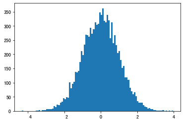

```python
## 範例 - random.normal
import numpy as np
import matplotlib.pyplot as plt

num = np.random.normal(0, 1, 10000)
n, bins, patches = plt.hist(num, 100)
plt.show()
```

```python
## 請猜猜以下執行結果

import numpy as np

num = np.arange(1, 10)
print(num)
num = np.arange(0.5, 5.5)
print(num)
num = np.arange(0.2, 0.8)
print(num)
num = np.arange(1, 2, 0.2)
print(num)
```

```python
## 請猜猜以下執行結果

import numpy as np

num = np.arange(3, dtype='float')
print(num)
num = np.arange(1, 5, dtype='int')
print(num)
num = np.arange(1, 5, dtype='float')
print(num)
num = np.arange(1, 2, 0.2, dtype='int')
print(num)
num = np.arange(0, 3, 0.5, dtype='int')
print(num)
```

## 當`arange`函數`step`使用浮點數時會產生精度問題.

## 因此`arange`實際上實作`step`時的方式為`dtype(start+step)-dtype(start)`

## 請自行練習`arange`函數

```python
## 請猜猜以下執行結果

num = np.arange(-3, 3, 0.5, dtype='int')
print(num)
num = np.arange(-1, 1, 0.2, dtype='int')
print(num)
```

## 常用數學函數

```
np.sum()
np.median()
np.mean()
np.dot()
ndarray_Variable.T
np.inner()
np.std()
np.var()
np.cov()
np.corrcoef()
```

```python
## 請猜猜以下執行結果

import numpy as np

num = np.arange(1, 9).reshape(2, 2, 2)
print(num)
print("- - - - -")
s1 = np.sum(num, axis=0)
print(s1)
print("- - - - -")
s2 = np.sum(num, axis=1)
print(s2)
print("- - - - -")
s2 = np.sum(num, axis=2)
print(s2)
```

```python
import numpy as np

num = np.random.randint(1, 100, 10).reshape(2, 5)
print(num)
## 請猜猜以下執行結果
m1 = np.amax(num, axis=1)
print(m1)
m2 = np.amin(num, axis=0)
print(m2)
```

```python
## 請猜猜以下執行結果

import numpy as np

A = np.array([[1, 2], [3, 4]])
B = np.array([[5, 6], [7, 8]])
print("A", A, sep="\n")
print("B", B, sep="\n")
print("inner", np.inner(A, B), sep="\n")
print("dot", np.dot(A, B), sep="\n")
print("A Transpose", A.T, sep="\n")
```

## 總練習 - 資料集下載

- [醫療保險金資料集](https://drive.google.com/file/d/1Bn7fk3fYmdMj3N2n-3BQuyrVjmnTZigp/view?usp=sharing)

## 總練習 - 資料集介紹

- `age(年齡):字串`
- `sex(性別):字串`
- `bmi:數值`
- `children(小孩個數):數值`
- `smoker(吸煙者):字串`
- `region(地區):字串`
- `charge(保金):數值`

## 總練習 - 請回答以下問題

- 該資料集共有幾個欄位、幾筆資料（扣除欄位）？
- sex欄位共有幾種值, 分別為哪些？
- 保醫療險的平均年齡為多少（取小數點後兩位）？
- 哪個地區的吸煙人數最多？